# Risk Factor Analysis

## Outcome Variable

**Outcome Variable:** sstunted

## Predictor Variables

**Intervention Variable:** rain_quartile

**Adjustment Set:**

unadjusted

## Stratifying Variables

The analysis was stratified on these variable(s):

- studyid
- country
- agecat

## Data Summary

| studyid | country | agecat | rain_quartile | sstunted | n_cell | n | outcome_variable |
| --- | --- | --- | --- | --- | --- | --- | --- |
| CMC-V-BCS-2002 | India | Birth | 1 | 0 | 17 | 92 | sstunted |
| CMC-V-BCS-2002 | India | Birth | 1 | 1 | 1 | 92 | sstunted |
| CMC-V-BCS-2002 | India | Birth | 2 | 0 | 23 | 92 | sstunted |
| CMC-V-BCS-2002 | India | Birth | 2 | 1 | 2 | 92 | sstunted |
| CMC-V-BCS-2002 | India | Birth | 3 | 0 | 30 | 92 | sstunted |
| CMC-V-BCS-2002 | India | Birth | 3 | 1 | 0 | 92 | sstunted |
| CMC-V-BCS-2002 | India | Birth | 4 | 0 | 18 | 92 | sstunted |
| CMC-V-BCS-2002 | India | Birth | 4 | 1 | 1 | 92 | sstunted |
| CMC-V-BCS-2002 | India | 6 months | 1 | 0 | 86 | 369 | sstunted |
| CMC-V-BCS-2002 | India | 6 months | 1 | 1 | 15 | 369 | sstunted |
| CMC-V-BCS-2002 | India | 6 months | 2 | 0 | 97 | 369 | sstunted |
| CMC-V-BCS-2002 | India | 6 months | 2 | 1 | 14 | 369 | sstunted |
| CMC-V-BCS-2002 | India | 6 months | 3 | 0 | 88 | 369 | sstunted |
| CMC-V-BCS-2002 | India | 6 months | 3 | 1 | 9 | 369 | sstunted |
| CMC-V-BCS-2002 | India | 6 months | 4 | 0 | 56 | 369 | sstunted |
| CMC-V-BCS-2002 | India | 6 months | 4 | 1 | 4 | 369 | sstunted |
| CMC-V-BCS-2002 | India | 24 months | 1 | 0 | 63 | 371 | sstunted |
| CMC-V-BCS-2002 | India | 24 months | 1 | 1 | 38 | 371 | sstunted |
| CMC-V-BCS-2002 | India | 24 months | 2 | 0 | 63 | 371 | sstunted |
| CMC-V-BCS-2002 | India | 24 months | 2 | 1 | 36 | 371 | sstunted |
| CMC-V-BCS-2002 | India | 24 months | 3 | 0 | 79 | 371 | sstunted |
| CMC-V-BCS-2002 | India | 24 months | 3 | 1 | 37 | 371 | sstunted |
| CMC-V-BCS-2002 | India | 24 months | 4 | 0 | 41 | 371 | sstunted |
| CMC-V-BCS-2002 | India | 24 months | 4 | 1 | 14 | 371 | sstunted |
| CMIN | Bangladesh | Birth | 1 | 0 | 5 | 26 | sstunted |
| CMIN | Bangladesh | Birth | 1 | 1 | 2 | 26 | sstunted |
| CMIN | Bangladesh | Birth | 2 | 0 | 5 | 26 | sstunted |
| CMIN | Bangladesh | Birth | 2 | 1 | 1 | 26 | sstunted |
| CMIN | Bangladesh | Birth | 3 | 0 | 5 | 26 | sstunted |
| CMIN | Bangladesh | Birth | 3 | 1 | 1 | 26 | sstunted |

[output cut: 506 more lines]

The following strata were considered:

- studyid: CMC-V-BCS-2002, country: India, agecat: 24 months
- studyid: CMC-V-BCS-2002, country: India, agecat: 6 months
- studyid: CMC-V-BCS-2002, country: India, agecat: Birth
- studyid: CMIN, country: Bangladesh, agecat: 24 months
- studyid: CMIN, country: Bangladesh, agecat: 6 months
- studyid: CMIN, country: Bangladesh, agecat: Birth
- studyid: CONTENT, country: Peru, agecat: 24 months
- studyid: CONTENT, country: Peru, agecat: 6 months
- studyid: CONTENT, country: Peru, agecat: Birth
- studyid: EE, country: Pakistan, agecat: 24 months
- studyid: EE, country: Pakistan, agecat: 6 months
- studyid: EE, country: Pakistan, agecat: Birth
- studyid: GMS-Nepal, country: Nepal, agecat: 24 months
- studyid: GMS-Nepal, country: Nepal, agecat: 6 months
- studyid: GMS-Nepal, country: Nepal, agecat: Birth
- studyid: Guatemala BSC, country: Guatemala, agecat: 6 months
- studyid: IRC, country: India, agecat: 24 months
- studyid: IRC, country: India, agecat: 6 months
- studyid: IRC, country: India, agecat: Birth
- studyid: JiVitA-3, country: Bangladesh, agecat: 24 months
- studyid: JiVitA-3, country: Bangladesh, agecat: 6 months
- studyid: JiVitA-3, country: Bangladesh, agecat: Birth
- studyid: JiVitA-4, country: Bangladesh, agecat: 24 months
- studyid: JiVitA-4, country: Bangladesh, agecat: 6 months
- studyid: JiVitA-4, country: Bangladesh, agecat: Birth
- studyid: Keneba, country: Gambia, agecat: 24 months
- studyid: Keneba, country: Gambia, agecat: 6 months
- studyid: Keneba, country: Gambia, agecat: Birth
- studyid: LCNI-5, country: Malawi, agecat: 24 months
- studyid: LCNI-5, country: Malawi, agecat: 6 months
- studyid: MAL-ED, country: Bangladesh, agecat: 24 months
- studyid: MAL-ED, country: Bangladesh, agecat: 6 months
- studyid: MAL-ED, country: Bangladesh, agecat: Birth
- studyid: MAL-ED, country: Brazil, agecat: 24 months
- studyid: MAL-ED, country: Brazil, agecat: 6 months
- studyid: MAL-ED, country: Brazil, agecat: Birth
- studyid: MAL-ED, country: India, agecat: 24 months
- studyid: MAL-ED, country: India, agecat: 6 months
- studyid: MAL-ED, country: India, agecat: Birth
- studyid: MAL-ED, country: Nepal, agecat: 24 months
- studyid: MAL-ED, country: Nepal, agecat: 6 months
- studyid: MAL-ED, country: Nepal, agecat: Birth
- studyid: MAL-ED, country: Peru, agecat: 24 months
- studyid: MAL-ED, country: Peru, agecat: 6 months
- studyid: MAL-ED, country: Peru, agecat: Birth
- studyid: MAL-ED, country: South Africa, agecat: 24 months
- studyid: MAL-ED, country: South Africa, agecat: 6 months
- studyid: MAL-ED, country: South Africa, agecat: Birth
- studyid: MAL-ED, country: Tanzania, agecat: 24 months
- studyid: MAL-ED, country: Tanzania, agecat: 6 months
- studyid: MAL-ED, country: Tanzania, agecat: Birth
- studyid: PROBIT, country: Belarus, agecat: 24 months
- studyid: PROBIT, country: Belarus, agecat: 6 months
- studyid: PROBIT, country: Belarus, agecat: Birth
- studyid: PROVIDE, country: Bangladesh, agecat: 24 months
- studyid: PROVIDE, country: Bangladesh, agecat: 6 months
- studyid: PROVIDE, country: Bangladesh, agecat: Birth
- studyid: ResPak, country: Pakistan, agecat: 6 months
- studyid: ResPak, country: Pakistan, agecat: Birth
- studyid: SAS-CompFeed, country: India, agecat: 6 months
- studyid: SAS-CompFeed, country: India, agecat: Birth
- studyid: SAS-FoodSuppl, country: India, agecat: 6 months
- studyid: TanzaniaChild2, country: Tanzania, agecat: 24 months
- studyid: TanzaniaChild2, country: Tanzania, agecat: 6 months
- studyid: ZVITAMBO, country: Zimbabwe, agecat: 24 months
- studyid: ZVITAMBO, country: Zimbabwe, agecat: 6 months
- studyid: ZVITAMBO, country: Zimbabwe, agecat: Birth

### Dropped Strata

Some strata were dropped due to rare outcomes:

- studyid: CMC-V-BCS-2002, country: India, agecat: Birth
- studyid: CMC-V-BCS-2002, country: India, agecat: 6 months
- studyid: CMIN, country: Bangladesh, agecat: Birth
- studyid: CMIN, country: Bangladesh, agecat: 6 months
- studyid: CONTENT, country: Peru, agecat: Birth
- studyid: CONTENT, country: Peru, agecat: 6 months
- studyid: CONTENT, country: Peru, agecat: 24 months
- studyid: EE, country: Pakistan, agecat: Birth
- studyid: EE, country: Pakistan, agecat: 6 months
- studyid: EE, country: Pakistan, agecat: 24 months
- studyid: GMS-Nepal, country: Nepal, agecat: Birth
- studyid: GMS-Nepal, country: Nepal, agecat: 6 months
- studyid: GMS-Nepal, country: Nepal, agecat: 24 months
- studyid: Guatemala BSC, country: Guatemala, agecat: 6 months
- studyid: IRC, country: India, agecat: Birth
- studyid: IRC, country: India, agecat: 6 months
- studyid: Keneba, country: Gambia, agecat: Birth
- studyid: MAL-ED, country: Bangladesh, agecat: Birth
- studyid: MAL-ED, country: Bangladesh, agecat: 6 months
- studyid: MAL-ED, country: Brazil, agecat: Birth
- studyid: MAL-ED, country: Brazil, agecat: 6 months
- studyid: MAL-ED, country: Brazil, agecat: 24 months
- studyid: MAL-ED, country: India, agecat: Birth
- studyid: MAL-ED, country: India, agecat: 6 months
- studyid: MAL-ED, country: Nepal, agecat: Birth
- studyid: MAL-ED, country: Nepal, agecat: 6 months
- studyid: MAL-ED, country: Nepal, agecat: 24 months
- studyid: MAL-ED, country: Peru, agecat: Birth
- studyid: MAL-ED, country: Peru, agecat: 6 months
- studyid: MAL-ED, country: Peru, agecat: 24 months
- studyid: MAL-ED, country: South Africa, agecat: Birth
- studyid: MAL-ED, country: South Africa, agecat: 6 months
- studyid: MAL-ED, country: South Africa, agecat: 24 months
- studyid: MAL-ED, country: Tanzania, agecat: Birth
- studyid: MAL-ED, country: Tanzania, agecat: 6 months
- studyid: PROBIT, country: Belarus, agecat: Birth
- studyid: PROVIDE, country: Bangladesh, agecat: Birth
- studyid: PROVIDE, country: Bangladesh, agecat: 6 months
- studyid: ResPak, country: Pakistan, agecat: Birth
- studyid: ResPak, country: Pakistan, agecat: 6 months
- studyid: TanzaniaChild2, country: Tanzania, agecat: 6 months
- studyid: TanzaniaChild2, country: Tanzania, agecat: 24 months

## Methods Detail

We’re interested in the causal parameters $E[Y_a]$ for all values of $a \in \mathcal{A}$. These parameters represent the mean outcome if, possibly contrary to fact, we intervened to set all units to have $A=a$. Under the randomization and positivity assumptions, these are identified by the statistical parameters $\psi_a=E_W[E_{Y|A,W}(Y|A=a,W)]$. In addition, we’re interested in the mean of $Y$, $E[Y]$ under no intervention (the observed mean). We will estimate these parameters by using SuperLearner to fit the relevant likelihood factors – $E_{Y|A,W}(Y|A=a,W)$ and $p(A=a|W)$, and then updating our likelihood fit using a joint TMLE.

For unadjusted analyses ($W=\{\}$), initial likelihoods were estimated using Lrnr_glm to estimate the simple $E(Y|A)$ and Lrnr_mean to estimate $p(A)$. For adjusted analyses, a small library containing Lrnr_glmnet, Lrnr_xgboost, and Lrnr_mean was used.

Having estimated these parameters, we will then use the delta method to estimate relative risks and attributable risks relative to a prespecified baseline level of $A$.

# Results Detail

## Results Plots

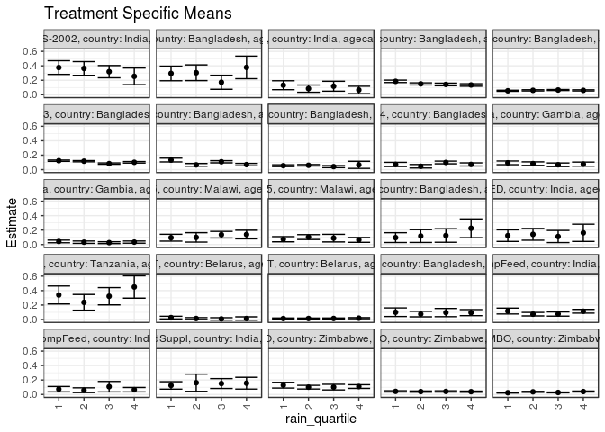

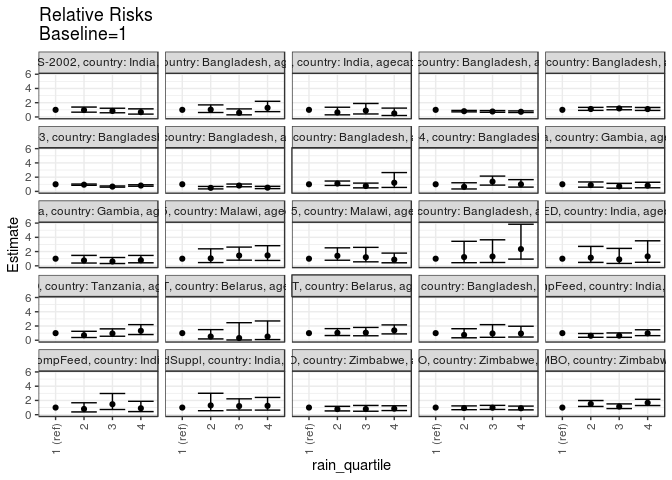

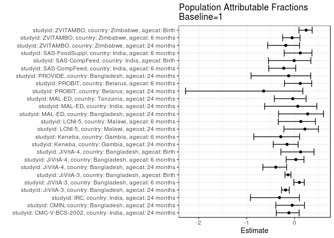

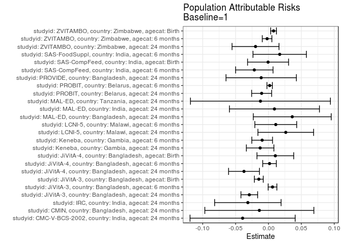

## Results Table

### Parameter: TSM

| studyid | country | agecat | intervention_level | baseline_level | estimate | ci_lower | ci_upper |
| --- | --- | --- | --- | --- | --- | --- | --- |
| CMC-V-BCS-2002 | India | 24 months | 1 | NA | 0.3762376 | 0.2816326 | 0.4708426 |
| CMC-V-BCS-2002 | India | 24 months | 2 | NA | 0.3636364 | 0.2687502 | 0.4585225 |
| CMC-V-BCS-2002 | India | 24 months | 3 | NA | 0.3189655 | 0.2340354 | 0.4038956 |
| CMC-V-BCS-2002 | India | 24 months | 4 | NA | 0.2545455 | 0.1392675 | 0.3698234 |
| CMIN | Bangladesh | 24 months | 1 | NA | 0.2948718 | 0.1934688 | 0.3962747 |
| CMIN | Bangladesh | 24 months | 2 | NA | 0.3043478 | 0.1955541 | 0.4131416 |
| CMIN | Bangladesh | 24 months | 3 | NA | 0.1724138 | 0.0749988 | 0.2698288 |
| CMIN | Bangladesh | 24 months | 4 | NA | 0.3783784 | 0.2217853 | 0.5349715 |
| IRC | India | 24 months | 1 | NA | 0.1315789 | 0.0694512 | 0.1937067 |
| IRC | India | 24 months | 2 | NA | 0.0840336 | 0.0341253 | 0.1339419 |
| IRC | India | 24 months | 3 | NA | 0.1176471 | 0.0490695 | 0.1862246 |
| IRC | India | 24 months | 4 | NA | 0.0659341 | 0.0148833 | 0.1169849 |
| JiVitA-3 | Bangladesh | Birth | 1 | NA | 0.1237035 | 0.1152388 | 0.1321682 |
| JiVitA-3 | Bangladesh | Birth | 2 | NA | 0.1166225 | 0.1085493 | 0.1246958 |
| JiVitA-3 | Bangladesh | Birth | 3 | NA | 0.0832614 | 0.0742528 | 0.0922701 |
| JiVitA-3 | Bangladesh | Birth | 4 | NA | 0.1013216 | 0.0910013 | 0.1116419 |
| JiVitA-3 | Bangladesh | 6 months | 1 | NA | 0.0545113 | 0.0471668 | 0.0618558 |
| JiVitA-3 | Bangladesh | 6 months | 2 | NA | 0.0607750 | 0.0526590 | 0.0688911 |
| JiVitA-3 | Bangladesh | 6 months | 3 | NA | 0.0652757 | 0.0582298 | 0.0723215 |
| JiVitA-3 | Bangladesh | 6 months | 4 | NA | 0.0603368 | 0.0525409 | 0.0681326 |
| JiVitA-3 | Bangladesh | 24 months | 1 | NA | 0.1850724 | 0.1686454 | 0.2014993 |
| JiVitA-3 | Bangladesh | 24 months | 2 | NA | 0.1498658 | 0.1353807 | 0.1643510 |
| JiVitA-3 | Bangladesh | 24 months | 3 | NA | 0.1417275 | 0.1235174 | 0.1599376 |
| JiVitA-3 | Bangladesh | 24 months | 4 | NA | 0.1347032 | 0.1173188 | 0.1520876 |
| JiVitA-4 | Bangladesh | Birth | 1 | NA | 0.0720721 | 0.0432026 | 0.1009416 |
| JiVitA-4 | Bangladesh | Birth | 2 | NA | 0.0462963 | 0.0217698 | 0.0708228 |
| JiVitA-4 | Bangladesh | Birth | 3 | NA | 0.0990854 | 0.0805090 | 0.1176617 |
| JiVitA-4 | Bangladesh | Birth | 4 | NA | 0.0717256 | 0.0503261 | 0.0931251 |
| JiVitA-4 | Bangladesh | 6 months | 1 | NA | 0.0544588 | 0.0419608 | 0.0669568 |
| JiVitA-4 | Bangladesh | 6 months | 2 | NA | 0.0600842 | 0.0505612 | 0.0696072 |

[output cut: 70 more lines]

### Parameter: E(Y)

| studyid | country | agecat | intervention_level | baseline_level | estimate | ci_lower | ci_upper |
| --- | --- | --- | --- | --- | --- | --- | --- |
| CMC-V-BCS-2002 | India | 24 months | NA | NA | 0.3369272 | 0.2887662 | 0.3850883 |
| CMIN | Bangladesh | 24 months | NA | NA | 0.2809917 | 0.2242434 | 0.3377401 |
| IRC | India | 24 months | NA | NA | 0.1002445 | 0.0711031 | 0.1293859 |
| JiVitA-3 | Bangladesh | Birth | NA | NA | 0.1090180 | 0.1044666 | 0.1135695 |
| JiVitA-3 | Bangladesh | 6 months | NA | NA | 0.0606746 | 0.0568229 | 0.0645262 |
| JiVitA-3 | Bangladesh | 24 months | NA | NA | 0.1559495 | 0.1472011 | 0.1646978 |
| JiVitA-4 | Bangladesh | Birth | NA | NA | 0.0825363 | 0.0708486 | 0.0942240 |
| JiVitA-4 | Bangladesh | 6 months | NA | NA | 0.0560960 | 0.0493335 | 0.0628586 |
| JiVitA-4 | Bangladesh | 24 months | NA | NA | 0.0953283 | 0.0857752 | 0.1048814 |
| Keneba | Gambia | 6 months | NA | NA | 0.0335089 | 0.0257898 | 0.0412279 |
| Keneba | Gambia | 24 months | NA | NA | 0.0811594 | 0.0682689 | 0.0940499 |
| LCNI-5 | Malawi | 6 months | NA | NA | 0.0846246 | 0.0657805 | 0.1034686 |
| LCNI-5 | Malawi | 24 months | NA | NA | 0.1208981 | 0.0943206 | 0.1474756 |
| MAL-ED | Bangladesh | 24 months | NA | NA | 0.1320755 | 0.0863920 | 0.1777589 |
| MAL-ED | India | 24 months | NA | NA | 0.1321586 | 0.0880054 | 0.1763117 |
| MAL-ED | Tanzania | 24 months | NA | NA | 0.3271028 | 0.2640978 | 0.3901078 |
| PROBIT | Belarus | 6 months | NA | NA | 0.0154178 | 0.0100323 | 0.0208033 |
| PROBIT | Belarus | 24 months | NA | NA | 0.0161090 | 0.0034156 | 0.0288025 |
| PROVIDE | Bangladesh | 24 months | NA | NA | 0.0899654 | 0.0666186 | 0.1133122 |
| SAS-CompFeed | India | Birth | NA | NA | 0.0726837 | 0.0523147 | 0.0930527 |
| SAS-CompFeed | India | 6 months | NA | NA | 0.0958084 | 0.0774939 | 0.1141229 |
| SAS-FoodSuppl | India | 6 months | NA | NA | 0.1421053 | 0.1069532 | 0.1772573 |
| ZVITAMBO | Zimbabwe | Birth | NA | NA | 0.0318559 | 0.0289336 | 0.0347781 |
| ZVITAMBO | Zimbabwe | 6 months | NA | NA | 0.0404891 | 0.0363397 | 0.0446385 |
| ZVITAMBO | Zimbabwe | 24 months | NA | NA | 0.1085366 | 0.0934775 | 0.1235957 |

### Parameter: RR

| studyid | country | agecat | intervention_level | baseline_level | estimate | ci_lower | ci_upper |
| --- | --- | --- | --- | --- | --- | --- | --- |
| CMC-V-BCS-2002 | India | 24 months | 1 | 1 | 1.0000000 | 1.0000000 | 1.0000000 |
| CMC-V-BCS-2002 | India | 24 months | 2 | 1 | 0.9665072 | 0.6727099 | 1.3886166 |
| CMC-V-BCS-2002 | India | 24 months | 3 | 1 | 0.8477768 | 0.5877995 | 1.2227391 |
| CMC-V-BCS-2002 | India | 24 months | 4 | 1 | 0.6765550 | 0.4030306 | 1.1357119 |
| CMIN | Bangladesh | 24 months | 1 | 1 | 1.0000000 | 1.0000000 | 1.0000000 |
| CMIN | Bangladesh | 24 months | 2 | 1 | 1.0321361 | 0.6285158 | 1.6949533 |
| CMIN | Bangladesh | 24 months | 3 | 1 | 0.5847076 | 0.3017745 | 1.1329089 |
| CMIN | Bangladesh | 24 months | 4 | 1 | 1.2831962 | 0.7492150 | 2.1977570 |
| IRC | India | 24 months | 1 | 1 | 1.0000000 | 1.0000000 | 1.0000000 |
| IRC | India | 24 months | 2 | 1 | 0.6386555 | 0.2990570 | 1.3638897 |
| IRC | India | 24 months | 3 | 1 | 0.8941176 | 0.4222870 | 1.8931352 |
| IRC | India | 24 months | 4 | 1 | 0.5010989 | 0.2023337 | 1.2410195 |
| JiVitA-3 | Bangladesh | Birth | 1 | 1 | 1.0000000 | 1.0000000 | 1.0000000 |
| JiVitA-3 | Bangladesh | Birth | 2 | 1 | 0.9427588 | 0.8586242 | 1.0351376 |
| JiVitA-3 | Bangladesh | Birth | 3 | 1 | 0.6730727 | 0.5937963 | 0.7629331 |
| JiVitA-3 | Bangladesh | Birth | 4 | 1 | 0.8190682 | 0.7236642 | 0.9270498 |
| JiVitA-3 | Bangladesh | 6 months | 1 | 1 | 1.0000000 | 1.0000000 | 1.0000000 |
| JiVitA-3 | Bangladesh | 6 months | 2 | 1 | 1.1149073 | 0.9243825 | 1.3447012 |
| JiVitA-3 | Bangladesh | 6 months | 3 | 1 | 1.1974706 | 1.0080955 | 1.4224205 |
| JiVitA-3 | Bangladesh | 6 months | 4 | 1 | 1.1068675 | 0.9186408 | 1.3336613 |
| JiVitA-3 | Bangladesh | 24 months | 1 | 1 | 1.0000000 | 1.0000000 | 1.0000000 |
| JiVitA-3 | Bangladesh | 24 months | 2 | 1 | 0.8097690 | 0.7142614 | 0.9180473 |
| JiVitA-3 | Bangladesh | 24 months | 3 | 1 | 0.7657951 | 0.6574082 | 0.8920517 |
| JiVitA-3 | Bangladesh | 24 months | 4 | 1 | 0.7278407 | 0.6234524 | 0.8497075 |
| JiVitA-4 | Bangladesh | Birth | 1 | 1 | 1.0000000 | 1.0000000 | 1.0000000 |
| JiVitA-4 | Bangladesh | Birth | 2 | 1 | 0.6423611 | 0.3406403 | 1.2113299 |
| JiVitA-4 | Bangladesh | Birth | 3 | 1 | 1.3748095 | 0.8804568 | 2.1467278 |
| JiVitA-4 | Bangladesh | Birth | 4 | 1 | 0.9951923 | 0.6004630 | 1.6494068 |
| JiVitA-4 | Bangladesh | 6 months | 1 | 1 | 1.0000000 | 1.0000000 | 1.0000000 |
| JiVitA-4 | Bangladesh | 6 months | 2 | 1 | 1.1032960 | 0.8370163 | 1.4542873 |

[output cut: 70 more lines]

### Parameter: PAR

| studyid | country | agecat | intervention_level | baseline_level | estimate | ci_lower | ci_upper |
| --- | --- | --- | --- | --- | --- | --- | --- |
| CMC-V-BCS-2002 | India | 24 months | 1 | NA | -0.0393104 | -0.1192885 | 0.0406677 |
| CMIN | Bangladesh | 24 months | 1 | NA | -0.0138801 | -0.0967927 | 0.0690326 |
| IRC | India | 24 months | 1 | NA | -0.0313344 | -0.0819049 | 0.0192360 |
| JiVitA-3 | Bangladesh | Birth | 1 | NA | -0.0146854 | -0.0214927 | -0.0078781 |
| JiVitA-3 | Bangladesh | 6 months | 1 | NA | 0.0061633 | -0.0004686 | 0.0127952 |
| JiVitA-3 | Bangladesh | 24 months | 1 | NA | -0.0291229 | -0.0418358 | -0.0164099 |
| JiVitA-4 | Bangladesh | Birth | 1 | NA | 0.0104642 | -0.0175107 | 0.0384392 |
| JiVitA-4 | Bangladesh | 6 months | 1 | NA | 0.0016372 | -0.0087008 | 0.0119753 |
| JiVitA-4 | Bangladesh | 24 months | 1 | NA | -0.0372366 | -0.0607066 | -0.0137666 |
| Keneba | Gambia | 6 months | 1 | NA | -0.0095946 | -0.0253887 | 0.0061995 |
| Keneba | Gambia | 24 months | 1 | NA | -0.0126530 | -0.0336178 | 0.0083119 |
| LCNI-5 | Malawi | 6 months | 1 | NA | 0.0110951 | -0.0207618 | 0.0429521 |
| LCNI-5 | Malawi | 24 months | 1 | NA | 0.0263035 | -0.0160615 | 0.0686685 |
| MAL-ED | Bangladesh | 24 months | 1 | NA | 0.0361851 | -0.0230940 | 0.0954641 |
| MAL-ED | India | 24 months | 1 | NA | 0.0090817 | -0.0593814 | 0.0775447 |
| MAL-ED | Tanzania | 24 months | 1 | NA | -0.0121829 | -0.1186420 | 0.0942761 |
| PROBIT | Belarus | 6 months | 1 | NA | 0.0018519 | -0.0022996 | 0.0060035 |
| PROBIT | Belarus | 24 months | 1 | NA | -0.0103750 | -0.0255691 | 0.0048191 |
| PROVIDE | Bangladesh | 24 months | 1 | NA | -0.0110447 | -0.0645761 | 0.0424867 |
| SAS-CompFeed | India | Birth | 1 | NA | -0.0005764 | -0.0317676 | 0.0306149 |
| SAS-CompFeed | India | 6 months | 1 | NA | -0.0215250 | -0.0500183 | 0.0069684 |
| SAS-FoodSuppl | India | 6 months | 1 | NA | 0.0171053 | -0.0235321 | 0.0577426 |
| ZVITAMBO | Zimbabwe | Birth | 1 | NA | 0.0077466 | 0.0033054 | 0.0121877 |
| ZVITAMBO | Zimbabwe | 6 months | 1 | NA | -0.0020641 | -0.0093788 | 0.0052506 |
| ZVITAMBO | Zimbabwe | 24 months | 1 | NA | -0.0196685 | -0.0553972 | 0.0160602 |

### Parameter: PAF

| studyid | country | agecat | intervention_level | baseline_level | estimate | ci_lower | ci_upper |
| --- | --- | --- | --- | --- | --- | --- | --- |
| CMC-V-BCS-2002 | India | 24 months | 1 | NA | -0.1166733 | -0.3812625 | 0.0972323 |
| CMIN | Bangladesh | 24 months | 1 | NA | -0.0493967 | -0.3900901 | 0.2077971 |
| IRC | India | 24 months | 1 | NA | -0.3125802 | -0.9191714 | 0.1022861 |
| JiVitA-3 | Bangladesh | Birth | 1 | NA | -0.1347065 | -0.1987251 | -0.0741069 |
| JiVitA-3 | Bangladesh | 6 months | 1 | NA | 0.1015793 | -0.0141697 | 0.2041177 |
| JiVitA-3 | Bangladesh | 24 months | 1 | NA | -0.1867455 | -0.2702482 | -0.1087321 |
| JiVitA-4 | Bangladesh | Birth | 1 | NA | 0.1267834 | -0.2845685 | 0.4064099 |
| JiVitA-4 | Bangladesh | 6 months | 1 | NA | 0.0291862 | -0.1739089 | 0.1971444 |
| JiVitA-4 | Bangladesh | 24 months | 1 | NA | -0.3906140 | -0.6592693 | -0.1654571 |
| Keneba | Gambia | 6 months | 1 | NA | -0.2863300 | -0.8495341 | 0.1053720 |
| Keneba | Gambia | 24 months | 1 | NA | -0.1559025 | -0.4441769 | 0.0748290 |
| LCNI-5 | Malawi | 6 months | 1 | NA | 0.1311102 | -0.3385954 | 0.4359987 |
| LCNI-5 | Malawi | 24 months | 1 | NA | 0.2175675 | -0.2204569 | 0.4983841 |
| MAL-ED | Bangladesh | 24 months | 1 | NA | 0.2739726 | -0.3326887 | 0.6044719 |
| MAL-ED | India | 24 months | 1 | NA | 0.0687179 | -0.6236519 | 0.4658422 |
| MAL-ED | Tanzania | 24 months | 1 | NA | -0.0372449 | -0.4195540 | 0.2421021 |
| PROBIT | Belarus | 6 months | 1 | NA | 0.1201152 | -0.2082543 | 0.3592431 |
| PROBIT | Belarus | 24 months | 1 | NA | -0.6440464 | -2.2731660 | 0.1742281 |
| PROVIDE | Bangladesh | 24 months | 1 | NA | -0.1227661 | -0.9063009 | 0.3387173 |
| SAS-CompFeed | India | Birth | 1 | NA | -0.0079298 | -0.5429098 | 0.3415542 |
| SAS-CompFeed | India | 6 months | 1 | NA | -0.2246667 | -0.5379087 | 0.0247740 |
| SAS-FoodSuppl | India | 6 months | 1 | NA | 0.1203704 | -0.2160319 | 0.3637105 |
| ZVITAMBO | Zimbabwe | Birth | 1 | NA | 0.2431754 | 0.0921440 | 0.3690811 |
| ZVITAMBO | Zimbabwe | 6 months | 1 | NA | -0.0509790 | -0.2480123 | 0.1149472 |
| ZVITAMBO | Zimbabwe | 24 months | 1 | NA | -0.1812158 | -0.5599416 | 0.1055622 |